## Top dogs

In this homework, you will try to reproduce the fantastic infographic for [top dogs](https://informationisbeautiful.net/visualizations/best-in-show-whats-the-top-data-dog/), originally produced by David McCandless. The raw data can be found [here](https://docs.google.com/spreadsheets/d/1l_HfF5EaN-QgnLc2UYdCc7L2CVrk0p3VdGB1godOyhk/edit#gid=10). You can download this file by File – Download As – Microsoft Excel (.xlsx).

**Submission instructions**: Create a folder named `ds202_hw6`, and name the RMarkDown file including your solutions `hw6.Rmd` under this folder. For the submission, create a GitHub repository named `ds202_hw6` under your GitHub account, and push both `hw6.Rmd` and the knitted `hw6.html` before the deadline. I will assume you use the same GitHub username as for your HW5 submission. The latest version of your homework appearing on GitHub before the deadline is graded. *It is crucial to follow the exact folder structure and file names*, so that your homework can be reproduced and graded by an automated script. This homework is **due on April 22** before class.

1. Import the data and clean appropriately. To read in the data, you can use `readxl::read_xlsx('fileNameHere', sheet='sheetNameHere')`. Required data are in the sheets `Best in show` and `Best in show full sheet`. Take extra care on the column names and the first few rows of the data frame after read in.

```r
# Libraries
library(readxl)
suppressMessages(library(tidyverse))
library(ggrepel)

# Import, skip column descriptions
dogs = suppressMessages(read_xlsx('dogs.xlsx', sheet='Best in show full sheet', skip=3))

# Select columns neeeded
dogs = dogs[, c(1, 3, 5, 6, 32, 41)]

# Rename columns
dogs = dogs %>% rename('breed' = 'Dog breed', 'Category' = 'American Kennel Club group', 'datadog_score' = '...5', 'popularity' = '1- 173, 1 = most poular, US. American Kennel Club registrations 2011, pure breeds only', 'Size' = '...32', 'Intelligence' = '...41')

# Prepare dog size
dogs$Size = ordered(dogs$Size, levels=c('small', 'medium', 'large'))
levels(dogs$Size) = c(1, 2, 3)
dogs$Size = as.numeric(dogs$Size)

# Prepare intelligence
dogs$Intelligence[which(dogs$Intelligence == "no data")] = NA
dogs$Intelligence = ordered(dogs$Intelligence, levels=c('Brighest', 'Excellent', 'Average' ,'Fair' ,'Lowest'))

# Prepare category
dogs$Category = factor(dogs$Category)

# Dataframe display
head(dogs)
```

```
## # A tibble: 6 x 6
##   breed                  Category datadog_score popularity  Size Intelligence
##   <chr>                  <fct>            <dbl>      <dbl> <dbl> <ord>
## 1 Border Collie          herding           3.64         45     2 <NA>
## 2 Border Terrier         terrier           3.61         80     1 <NA>
## 3 Brittany               sporting          3.54         30     2 Excellent
## 4 Cairn Terrier          terrier           3.53         59     1 <NA>
## 5 Welsh Springer Spaniel sporting          3.34        130     2 <NA>
## 6 English Cocker Spaniel sporting          3.33         63     2 Excellent
```

# Please grade the plot based on the exported plot in the same folder as this RMD (named best_in_show.png) - this stretches out the plot so it is visible.

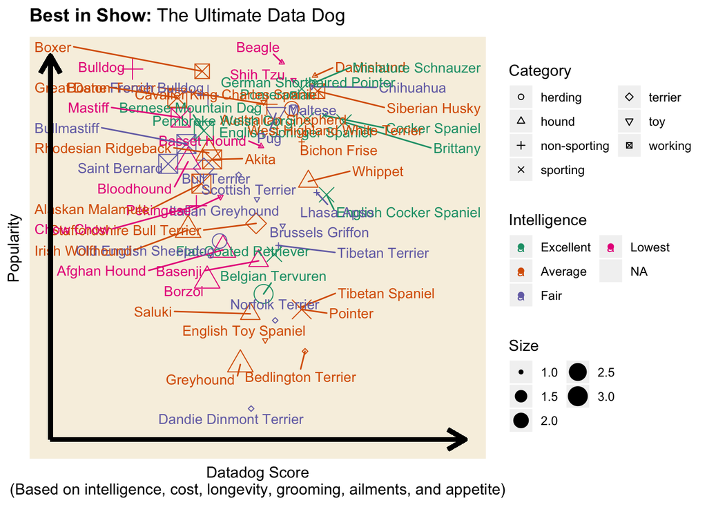

```r
# Point plot
p = dogs %>% ggplot(aes(x=datadog_score, y=popularity, text=breed, size=Size, color=Intelligence, shape=Category)) + geom_point() + scale_y_reverse() + scale_shape_manual(values=1:nlevels(dogs$Category), na.translate = FALSE)

# Labels
p = p + geom_text_repel(aes(label=breed), size=3.5) + xlab('Datadog Score\n(Based on intelligence, cost, longevity, grooming, ailments, and appetite)') + ylab('Popularity') + ggtitle(expression(paste(bold('Best in Show: '), 'The Ultimate Data Dog')))

# Axis arrows
p = p + geom_segment(aes(x=0, xend = 5 , y=174, yend = 174), size=1.5, arrow = arrow(length = unit(0.5,"cm")), color='black')
p = p + geom_segment(aes(x=0, xend = 0 , y=174, yend = 0), size=1.5, arrow = arrow(length = unit(0.5,"cm")), color='black')

# Theme
p = p + theme(axis.ticks = element_blank(), axis.text = element_blank(), panel.grid.major = element_blank(), panel.grid.minor = element_blank(), panel.background = element_rect(fill = "#F7F0E1", size = 0)) + guides(color = guide_legend(nrow = 3), shape = guide_legend(nrow = 4), size = guide_legend(nrow = 3)) + scale_color_brewer(palette="Dark2")

p
```

```r
# Save the plot to a png
aspect_ratio = 2.5
ggsave("best_in_show.png", p, height = 7, width = 6 * aspect_ratio, device=NULL)
```